# BOO 2025 - Example Analysis

Script 2: Probe QC - Questions

Hala Saab

2025-05-13

> In this script, you will perform probe-level quality control (QC), ensuring that the final data set contains only well-expressed, relevant genes.

# 1 Setup

## 1.1 Clean

As before, we perform several setup steps at the start of the script to ensure our work is reproducible and clear.

**Exercise 1: Download the R markdown template and clean your environment.**

**Hint**

Use the code dropdown menu in the top right corner of this document.

```r
#clean My environment

ls()
```

```
## character(0)
```

## 1.2 Load packages

Here, we introduce a second package:

- `readxl` allows you to read in Excel files, such as the probe manifest

**Exercise 2: Load `tidyverse` and `readxl` into your R environment**

**Hint**

You may need to install packages before you load them for the first time with the `install.packages()` function.

```r
# Load the `tidyverse` package
library(tidyverse)
library(readxl)
```

## 1.3 Set variables

As before, we set directories and commonly used variables at the start of the script to make it easier to adjust anything later.

**Exercise 3: Create the following objects:**

- `root_dir` - the root directory for your project
- `count_path` - the location of the count data
- `metadata_path` - the location of the metadata
- `manifest path` - the probe manifest for TempO-Seq probes
- `count_store` - where you want to save the count data after QC
- `cpm_store` - where you want to store the CPM data
- `metadata_store` - where you want to save the metadata
- `probedata_store` - where to store the updated manifest

```r
count_file_path <- file.path("input/countData.txt")

metadata_file_path <- file.path("input/metaData.txt")

manifest_file_path <- file.path("input/Human.xlsx")


output_dir <- "output"
if (!dir.exists(output_dir)) {
  dir.create(output_dir)
  cat("Created directory:", output_dir, "\n")
}

count_store <- file.path(output_dir, "qc_countData.RData")
cpm_store <- file.path(output_dir, "cpm_data.RData")
metadata_store <- file.path(output_dir, "processed_metaData.RData")
probedata_store <- file.path(output_dir, "processed_probeData.RData")
```

## 1.4 Load data

For the probe QC, we will use the count data, metadata, and probe manifest.

**Exercise 4: Load required data into the environment:**

**Hint**

The `read_xlsx()` function from the `readxl` package can be used to read in Excel files.

```r
#Load required data into the environment

#countData <- data.table::fread("out/countData.txt", sep = "\t")
#metaDaat <- data.table::fread("input/metaData.txt", sep = "\t")
load("output/countData.Rdata")
load("output/metaData.Rdata")

manifest <- read_excel("input/Human.xlsx", sheet = 1)
```

# 2 Annotation

## 2.1 Motivation

In TempO-Seq, each gene is detected using a unique probe sequence. In order to ensure accuracy in our gene annotations and downstream analyses, we need to confirm that these probes align to the locations on the genome that we expect them to.

To do this, we used [NCBI BLAST (Basic Local Alignment Search Tool)](https://blast.ncbi.nlm.nih.gov/Blast.cgi), a tool that allows us to compare the probe sequences against a reference genome database. By uploading our probe sequences to BLAST, we could:

1. Verify that each probe still uniquely matches the gene it was designed for,
2. Check for any outdated or incorrect annotations, especially since the genome has been updated since the probes were designed, and
3. Update our manifest file (the reference file we use to link probe names to gene IDs in this script).

**Exercise 5: What problems could arise in your project if you did not update the probe annotations?** If you don’t update probe annotations, you risk:

Measuring the wrong genes: Probes might hit different genes than intended, obsolete genes, or multiple targets due to changes in the reference genome. This leads to incorrect gene expression values.

Flawed biological insights: Analyses like differential expression, pathway enrichment, or biomarker discovery would be based on inaccurate data, leading to misleading or incorrect conclusions about biological processes.

Poor comparability and integration: Your results would be hard to compare with other studies or integrate with public databases that use up-to-date annotations, reducing the value and context of your work. Wasted effort: Time and resources might be spent analyzing and validating findings that are ultimately artifacts of poor probe mapping.

## 2.2 Update

The manifest provided during this project contains updated information about the probes.

**Exercise 6: Describe the columns in the probe manifest**

```r
#the column headers
print(colnames(manifest))
```

```
##  [1] "probe_name_old"   "probe_ID"         "probe_sequence"   "probe_coord"
##  [5] "gene_symbol"      "entrez_id"        "ensembl_id"       "hgnc_id"
##  [9] "gene_symbol_old"  "entrez_id_old"    "percentage_match"
```

```r
#  compact summary of the data structure, including:
str(manifest)
```

```
## tibble [22,533 × 11] (S3: tbl_df/tbl/data.frame)
##  $ probe_name_old  : chr [1:22533] "A1BG_25586" "A1CF_87905" "A2ML1_18347" "A2M_1" ...
##  $ probe_ID        : num [1:22533] 25586 87905 18347 1 12371 ...
##  $ probe_sequence  : chr [1:22533] "TCAGGCACCTCCAGAAACTCATGGTCGCCCTCCCGCCTCAGCAGAAAAGT" "GATGACTCTCATACTCCACGAAGGCAAAGCCTCGGTTTTTGGTTTTATCT" "ATGACCCTGCCCATGCAACGCCTCCTCTGAGTGATTGTTCCTATCCCATC" "GAACAGGACTCCAGCAAAGCACTTTTCAGCCTTGTGGTCTTCAAGCATTT" ...
##  $ probe_coord     : chr [1:22533] "19:58352407-58352456:-" "10:50836109-50836158:-" "12:8876237-8876286:+" "12:9067782-9067831:-" ...
##  $ gene_symbol     : chr [1:22533] "A1BG" "A1CF" "A2ML1" "A2M" ...
##  $ entrez_id       : num [1:22533] 1 29974 144568 2 2 ...
##  $ ensembl_id      : chr [1:22533] "ENSG00000121410" "ENSG00000148584" "ENSG00000166535" "ENSG00000175899" ...
##  $ hgnc_id         : num [1:22533] 5 24086 23336 7 7 ...
##  $ gene_symbol_old : chr [1:22533] "A1BG" "A1CF" "A2ML1" "A2M" ...
##  $ entrez_id_old   : num [1:22533] 1 29974 144568 2 2 ...
##  $ percentage_match: num [1:22533] 100 100 100 100 100 100 100 100 100 100 ...
```

probe_name_old: Character (chr). An original or previous identifier for the probe, often combining a gene-like name and a numeric ID probe_ID: Numeric (num). The current primary unique identifier for each TempO-Seq probe. probe_sequence: Character (chr). The actual nucleotide sequence of the oligonucleotide probe. probe_coord: Character (chr). Genomic coordinates indicating where the probe sequence aligns, likely in a format like “chromosome:start-end:strand”. gene_symbol: Character (chr). The current official HUGO gene symbol targeted by the probe (e.g., “A1BG”). entrez_id: Numeric (num). The Entrez Gene ID (from NCBI) for the targeted gene (e.g., 1). ensembl_id: Character (chr). The Ensembl Gene ID for the targeted gene (e.g., “ENSG00000121410”). hgnc_id: Numeric (num). The HGNC ID (from the HUGO Gene Nomenclature Committee) for the targeted gene (e.g., 5). gene_symbol_old: Character (chr). An older or previously used gene symbol associated with this probe or its target (e.g., “A1BG”). entrez_id_old: Numeric (num). An older or previously used Entrez Gene ID associated with this probe or its target (e.g., 1). percentage_match: Numeric (num). The percentage identity of the probe sequence’s alignment to its target in the reference genome, likely from a BLAST analysis (e.g., 100, indicating a perfect match). ***

**Exercise 7: Check that we have annotation information for all of the probes in `countData`:**

```r
#Number of unique my manifest has information for, based on that specific identifier.
length(unique(manifest$probe_name_old))
```

```
## [1] 22533
```

```r
# Get the probe identifiers from countData's row names
probes_in_countData <- rownames(countData)

# Get the probe identifiers from the manifest (using the column we think matches)
probes_in_manifest_column <- unique(manifest$probe_name_old)

# Check if all probes from countData are present in the manifest's list
all_probes_annotated <- all(probes_in_countData %in% probes_in_manifest_column)

# Print the result of this check
print(all_probes_annotated)
```

```
## [1] TRUE
```

This True result means that all probe identifiers found as row names in countData are present in the manifest$probe_name_old column. ***

Sometimes, the probe sequence could no longer be aligned to a specific gene in the reference genome. In this instance, the `gene_symbol` column will be NA.

**Exercise 8: How many probes could not be aligned in the updated manifest? What should be do with these probes and why?**

```r
# These are probes that could not be confidently mapped to a current gene symbol.
probes_with_na_gene_symbol <- manifest %>%
  filter(is.na(gene_symbol))

# 2. Count how many such probes exist
number_of_na_gene_symbol_probes <- nrow(probes_with_na_gene_symbol)

print(number_of_na_gene_symbol_probes)
```

```
## [1] 603
```

```r
# 3. If there are probes with NA gene_symbol, display some information about them
if (number_of_na_gene_symbol_probes > 0) {
  cat("Details for some probes with NA for 'gene_symbol'")
  print(head(probes_with_na_gene_symbol %>%
               select(probe_ID, probe_name_old, probe_sequence, gene_symbol_old, entrez_id_old, percentage_match)))
} else {
  cat("Good news: All probes in the manifest have a non-NA 'gene_symbol'.\n")
}
```

```
## Details for some probes with NA for 'gene_symbol'# A tibble: 6 × 6
##   probe_ID probe_name_old   probe_sequence         gene_symbol_old entrez_id_old
##      <dbl> <chr>            <chr>                  <chr>                   <dbl>
## 1    92347 ABCF2_92347      CGCACTCGTCCTCGCCCGCGT… ABCF2                      NA
## 2    92349 ABCF2_92349      TTACTAGTAAGAATGCCTGGG… ABCF2                      NA
## 3    28160 AC007406.5_28160 TAGAGAAATAGCCAACAGAGT… AC007406.5                 NA
## 4    22102 AC073648.1_22102 ACAGTCAGGATCATGCCTTCT… AC073648.1                 NA
## 5    33621 AC104389.4_33621 TCAAGTTTGCCTTGTCAAGGC… AC104389.4                 NA
## 6    33866 ACOT1_33866      ATGACGACAGCAGCCGTGATG… ACOT1                      NA
## # ℹ 1 more variable: percentage_match <dbl>
```

There is 603 probes could not be aligned in the updated manifest The standard and recommended approach is to remove these 603 probes from your countData (if they are present there after the previous matching exercise) and also from your manifest before proceeding with downstream analyses like differential gene expression. ***

**Exercise 9: How many probes have had their annotation updated by the manifest?**

**Hint**

The annotation is updated if the old and updated `gene_symbol` do not match.

```r
# 1. Identify probes where the 'gene_symbol' and 'gene_symbol_old' indicate an update.
# An update occurs if:
#   a) Both had symbols, but they are different.
#   b) One had a symbol, and the other is NA (or vice-versa).
updated_annotation_probes <- manifest %>%
 filter(
    # Case 1: Both old and new gene symbols exist (are not NA) AND they are different
    (!is.na(gene_symbol_old) & !is.na(gene_symbol) & gene_symbol_old != gene_symbol) |
    # Case 2: Old gene symbol existed, but new gene symbol is NA (annotation lost)
    (!is.na(gene_symbol_old) & is.na(gene_symbol)) |
    # Case 3: Old gene symbol was NA, but new gene symbol exists (annotation gained)
    (is.na(gene_symbol_old) & !is.na(gene_symbol))
 )

print(updated_annotation_probes)
```

```
## # A tibble: 1,211 × 11
##    probe_name_old   probe_ID probe_sequence    probe_coord gene_symbol entrez_id
##    <chr>               <dbl> <chr>             <chr>       <chr>           <dbl>
##  1 ABCF2_92347         92347 CGCACTCGTCCTCGCC… 7:15122694… <NA>               NA
##  2 ABCF2_92349         92349 TTACTAGTAAGAATGC… 7:15122653… <NA>               NA
##  3 AC002116.2_11937    11937 AACTCCATTTCCAGGT… 19:3601687… LOC1019275… 101927572
##  4 AC007342.3_17969    17969 ATCTTTGTTGTTCACA… 16:5337025… MPHOSPH10P1    643802
##  5 AC007406.5_28160    28160 TAGAGAAATAGCCAAC… 12:276978-… <NA>               NA
##  6 AC007666.1_28481    28481 GCTAAACCTGGCATGA… 22:1758869… LOC1019293… 101929372
##  7 AC008397.1_89032    89032 GGTTCCCCTGAACTGT… 19:1825237… CIST1          729966
##  8 AC008687.4_88136    88136 ATAATGCGGTGGGAAA… 19:4902040… SAXO3       101059948
##  9 AC010255.3_24596    24596 CTGGCAGGAAGGTACG… 5:12218254… ZNF475      100505841
## 10 AC010442.1_5295      5295 GGCTGCCGTGAGTGAG… 5:471049-4… SLC9A3           6550
## # ℹ 1,201 more rows
## # ℹ 5 more variables: ensembl_id <chr>, hgnc_id <dbl>, gene_symbol_old <chr>,
## #   entrez_id_old <dbl>, percentage_match <dbl>
```

```r
# Count how many such probes exist
nrow(updated_annotation_probes)
```

```
## [1] 1211
```

**Exercise 10: Create `flag_realignment`, a new column in `probeManifest` which describes whether a probe should be removed, renamed, or kept unchanged:**

**Hint**

Try using `case_when()` inside the `mutate()` function.

```r
#
manifest <- manifest %>%
    mutate(
      flag_realignment = case_when(
        is.na(gene_symbol) ~ "Remove",
        !is.na(gene_symbol_old) & !is.na(gene_symbol) & (gene_symbol_old != gene_symbol) ~ "Rename",
        TRUE ~ "Keep Unchanged"
      )
    )
print (manifest)
```

```
## # A tibble: 22,533 × 12
##    probe_name_old probe_ID probe_sequence      probe_coord gene_symbol entrez_id
##    <chr>             <dbl> <chr>               <chr>       <chr>           <dbl>
##  1 A1BG_25586        25586 TCAGGCACCTCCAGAAAC… 19:5835240… A1BG                1
##  2 A1CF_87905        87905 GATGACTCTCATACTCCA… 10:5083610… A1CF            29974
##  3 A2ML1_18347       18347 ATGACCCTGCCCATGCAA… 12:8876237… A2ML1          144568
##  4 A2M_1                 1 GAACAGGACTCCAGCAAA… 12:9067782… A2M                 2
##  5 A2M_12371         12371 CTTCAGGTTCAACCAACA… 12:9089244… A2M                 2
##  6 A3GALT2_23042     23042 CCGTCTCCAGGAAGCGCT… 1:33307415… A3GALT2        127550
##  7 A4GALT_88955      88955 CACGTTGGTCAGGTTCCG… 22:4269333… A4GALT          53947
##  8 A4GNT_89151       89151 CTGGGACAGTGCTTGCGA… 3:13812433… A4GNT           51146
##  9 AAAS_23947        23947 ACAATCGTTGCTGACTTT… 12:5330848… AAAS             8086
## 10 AACS_17112        17112 CAATTCCACTGAATTTCC… 12:1250739… AACS            65985
## # ℹ 22,523 more rows
## # ℹ 6 more variables: ensembl_id <chr>, hgnc_id <dbl>, gene_symbol_old <chr>,
## #   entrez_id_old <dbl>, percentage_match <dbl>, flag_realignment <chr>
```

If probes could not be aligned, they should be removed from the `countData`.

**Exercise 11: Subset `countData` to keep only the probes with correct annotations.**

```r
if (exists("manifest") && ("flag_realignment" %in% colnames(manifest)) &&
    exists("countData")) {

 identifiers_to_keep_from_manifest <- manifest %>%
    filter(flag_realignment != "Remove") %>% # Keeps "Keep Unchanged" and "Rename"
    pull(probe_name_old)
 filtered_countData <- countData[rownames(countData) %in% identifiers_to_keep_from_manifest, , drop = FALSE]

if (nrow(filtered_countData) == 0 && length(identifiers_to_keep_from_manifest) > 0) {
    cat("CRITICAL WARNING: 'filtered_countData' is empty (0 rows).\n")
    cat("This strongly indicates that the identifiers in 'manifest$probe_name_old' (for probes to keep)\n")
    cat("do NOT match the 'rownames(countData)'. Please resolve the identifier format mismatch.\n")
  } else if (nrow(filtered_countData) > 0) {
    cat("Successfully created 'filtered_countData'.\n")
    cat("First few rows and columns of 'filtered_countData':\n")
    print(head(filtered_countData[, 1:min(5, ncol(filtered_countData))]))
  } else {
    cat("'filtered_countData' is empty. This might also be because no probes were flagged to keep in the manifest.\n")
  }

} else {
  cat("ERROR: 'manifest' (with 'flag_realignment' column) and/or 'countData' objects not found,\n")
  cat("or 'manifest' is not a valid data frame/tibble, or 'flag_realignment' column is missing.\n")
  cat("Please ensure these were loaded and processed correctly in previous steps.\n")
}
```

```
## Successfully created 'filtered_countData'.
## First few rows and columns of 'filtered_countData':
##          CS1106_C1_P1_R1 CS1106_C1_P1_R2 CS1106_C1_P1_R3 CS1106_C2_P1_R1
## A2M_1                 13              20              17               7
## AAMP_2               342             375             386             345
## AARS1_3              513             501             424             645
## AATF_4                 8               6               9               8
## ABCB1_12             347             330             378             356
## ABCC2_22             586             653             792             497
##          CS1106_C2_P1_R2
## A2M_1                 10
## AAMP_2               303
## AARS1_3              486
## AATF_4                 3
## ABCB1_12             319
## ABCC2_22             694
```

```r
countData <- filtered_countData

# Resolved the critical identifier mismatch issue we seen earlier.I am ensuring that the expression data you carry forward into downstream analysis is associated with reliably annotated probes.
```

As well as removing probes that could not be annotated, we also want to update the names of probes where the gene name has changed.

**Exercise 12: Create `probe_name`, a new column in `probeManifest` that contains the updated probe names, and adjust the `countData` row names accordingly:**

**Hint**

The new probe name should be a combination of `gene_symbol` and `probe_ID`.

```r
#Create the new 'probe_name' column in the entire 'manifest'
manifest <- manifest %>%
  mutate(
    probe_name = paste(gene_symbol, probe_ID, sep = "_") # New name format: GENESYMBOL_PROBEID
  )
# Part 2: Prepare to update countData row names
manifest_for_kept_probes <- manifest %>%
  filter(flag_realignment != "Remove")
# Create a lookup map:
name_update_map <- setNames(manifest_for_kept_probes$probe_name,
                            manifest_for_kept_probes$probe_name_old)
# Get current row names of countData
current_row_names_in_countData <- rownames(countData)
new_row_names_for_countData <- name_update_map[current_row_names_in_countData]

# Update the row names of countData
rownames(countData) <- new_row_names_for_countData
# show the updated row names
cat("First few rows/cols of countData with updated row names (new format: GENESYMBOL_PROBEID):\n")
```

```
## First few rows/cols of countData with updated row names (new format: GENESYMBOL_PROBEID):
```

```r
print(head(countData[, 1:min(5, ncol(countData))]))
```

```
##          CS1106_C1_P1_R1 CS1106_C1_P1_R2 CS1106_C1_P1_R3 CS1106_C2_P1_R1
## A2M_1                 13              20              17               7
## AAMP_2               342             375             386             345
## AARS1_3              513             501             424             645
## AATF_4                 8               6               9               8
## ABCB1_12             347             330             378             356
## ABCC2_22             586             653             792             497
##          CS1106_C2_P1_R2
## A2M_1                 10
## AAMP_2               303
## AARS1_3              486
## AATF_4                 3
## ABCB1_12             319
## ABCC2_22             694
```

The row names of your countData have been updated to the new format (e.g., “A2M_1”, “AAMP_23”). This means the previous issues with NA values or duplicate new row names have been resolved ————————————————————————

It is good practice to check the dimensions of objects when making such adjustments using the `dim()` function.

**Exercise 13: Check the dimensions of the objects in your environments to ensure nothing went wrong:**

```r
#Check dimensions of countData
if (exists("countData") && (is.data.frame(countData) || is.matrix(countData))) {
  cat("Dimensions of 'countData':\n")
  print(dim(countData)) # dim() returns rows then columns
  cat("   Number of probes (rows):", nrow(countData), "\n")
  cat("   Number of samples (columns):", ncol(countData), "\n\n")
} else {
  cat("WARNING: 'countData' object not found or is not a data frame/matrix.\n\n")
}
```

```
## Dimensions of 'countData':
## [1] 21930    60
##    Number of probes (rows): 21930
##    Number of samples (columns): 60
```

```r
# Check dimensions of metaData
if (exists("metaData") && (is.data.frame(metaData) || tibble::is_tibble(metaData))) {
  cat("Dimensions of 'metaData':\n")
  print(dim(metaData))
  cat("   Number of samples (rows):", nrow(metaData), "\n")
  cat("   Number of metadata variables (columns):", ncol(metaData), "\n\n")
} else {
  cat("WARNING: 'metaData' object not found or is not a data frame/tibble.\n\n")
}
```

```
## Dimensions of 'metaData':
## [1] 60 29
##    Number of samples (rows): 60
##    Number of metadata variables (columns): 29
```

```r
# Check dimensions of manifest
if (exists("manifest") && (is.data.frame(manifest) || tibble::is_tibble(manifest))) {
  cat("Dimensions of 'manifest':\n")
  print(dim(manifest))
  cat("   Number of probes/entries (rows):", nrow(manifest), "\n")
  cat("   Number of annotation columns:", ncol(manifest), "\n\n")
} else {
  cat("WARNING: 'manifest' object not found or is not a data frame/tibble.\n\n")
}
```

```
## Dimensions of 'manifest':
## [1] 22533    13
##    Number of probes/entries (rows): 22533
##    Number of annotation columns: 13
```

```r
# In the countData. I started with 22,533 probes. In Exercise 8, I identified 603 probes with no gene_symbol. In Exercise 11, I subsetted countData to remove these probes. So, 22533 - 603 = 21930 probes remaining is correct.

# MetaData object has not been altered in terms of its number of samples (rows) or variables (columns).The manifest started with 22,533 probes and 11 columns. In Exercise 10, We added the flag_realignment column, and in Exercise 12, We added the probe_name column. So, 11 + 2 = 13 columns is expected.
```

# 3 Normalization

## 3.1 CPM

Counts Per Million (CPM) normalization is a method that accounts for differences in sequencing depth between samples. It scales raw read counts (as in `countData`) so that the total counts per sample sum to one million. This allows for comparison of gene expression levels across samples.

**Exercise 14: Calculate CPM values for our data and store them in a `cpmData` object:**

```r
#alculate library sizes (total counts per sample)

library_sizes <- colSums(countData)
print(head(library_sizes))
```

```
## CS1106_C1_P1_R1 CS1106_C1_P1_R2 CS1106_C1_P1_R3 CS1106_C2_P1_R1 CS1106_C2_P1_R2
##         3232071         2997918         3480381         3355663         3051648
## CS1106_C2_P1_R3
##         3330525
```

```r
# Calculate CPM values: Divide each column by its library size, Then Multiply by one million to get CPM
proportions_data <- sweep(countData, MARGIN = 2, STATS = library_sizes, FUN = "/")
cpmData <- proportions_data * 1e6 # 1e6 is 1,000,000

cat("Successfully calculated CPM values and stored them in 'cpmData'.\n")
```

```
## Successfully calculated CPM values and stored them in 'cpmData'.
```

```r
cat("Dimensions of 'cpmData': ",
    nrow(cpmData), "rows (probes/genes), ", ncol(cpmData), "columns (samples)\n\n")
```

```
## Dimensions of 'cpmData':  21930 rows (probes/genes),  60 columns (samples)
```

```r
print(head(cpmData[, 1:min(5, ncol(cpmData))]))
```

```
##          CS1106_C1_P1_R1 CS1106_C1_P1_R2 CS1106_C1_P1_R3 CS1106_C2_P1_R1
## A2M_1           4.022189        6.671297        4.884523        2.086026
## AAMP_2        105.814507      125.086810      110.907398      102.811278
## AARS1_3       158.721761      167.115978      121.825743      192.212388
## AATF_4          2.475193        2.001389        2.585924        2.384030
## ABCB1_12      107.361503      110.076393      108.608799      106.089318
## ABCC2_22      181.307898      217.817832      227.561293      148.107840
##          CS1106_C2_P1_R2
## A2M_1          3.2769179
## AAMP_2        99.2906128
## AARS1_3      159.2582106
## AATF_4         0.9830754
## ABCB1_12     104.5336815
## ABCC2_22     227.4181033
```

```r
# The total number of raw counts (library size) for the first few samples in your countData. For example, sample CS1106_C1_P1_R1 has a total of 3,232,071 counts.

# The cpmData object was created and has the same dimensions as your filtered countData (21930 probes/genes and 60 samples), which is expected.

# The values are now Counts Per Million (CPM). We can see they are no longer integers (like raw counts) and have been scaled.
```

# 4 Probe relevance

## 4.1 Highly expressed genes

By inspecting the most highly expressed genes in a dataset, you can build confidence in the data and get an idea of processes with particular relevance to your project.

**Exercise 15: Add the columns `total_cpm` and `average_cpm` to the probe manifest and describe a few of the most highly expressed genes. Do they make biological sense?**

**Hint**

You can look up gene functions using [NCBI](https://www.ncbi.nlm.nih.gov/gene/) or [GeneCards](https://www.genecards.org/).

```r
#Calculate total CPM and average CPM for each probe from cpmData
total_cpm_per_probe <- rowSums(cpmData)
average_cpm_per_probe <- rowMeans(cpmData)

# 2. Create a data frame with these summary statistics.
cpm_summary_stats <- data.frame(
  probe_name = rownames(cpmData), # This should match 'probe_name' in manifest for kept probes
  total_cpm = total_cpm_per_probe,
  average_cpm = average_cpm_per_probe
)
print(head(cpm_summary_stats, 3))
```

```
##         probe_name  total_cpm average_cpm
## A2M_1        A2M_1   299.5212    4.992021
## AAMP_2      AAMP_2  6654.8969  110.914949
## AARS1_3    AARS1_3 10287.4124  171.456873
```

```r
# Add these new columns to the 'manifest' data frame.

manifest <- manifest %>%
  left_join(cpm_summary_stats, by = "probe_name")

# Identify and display some of the most highly expressed genes.
top_expressed_probes <- manifest %>%
  filter(flag_realignment != "Remove") %>% # Focus on probes we intend to keep/use
  arrange(desc(average_cpm)) %>%
  select(probe_name, gene_symbol, probe_ID, average_cpm, total_cpm, flag_realignment, percentage_match)

# Print the top N probes. R Markdown will format this as a paged table.
print(head(top_expressed_probes, 10))
```

```
## # A tibble: 10 × 7
##    probe_name  gene_symbol probe_ID average_cpm total_cpm flag_realignment
##    <chr>       <chr>          <dbl>       <dbl>     <dbl> <chr>
##  1 HP_3085     HP              3085       8140.   488400. Keep Unchanged
##  2 HSPB1_92509 HSPB1          92509       5073.   304360. Keep Unchanged
##  3 APOA1_87403 APOA1          87403       4454.   267217. Keep Unchanged
##  4 ALB_217     ALB              217       3860.   231595. Keep Unchanged
##  5 APOC3_15165 APOC3          15165       3694.   221658. Keep Unchanged
##  6 ORM1_4833   ORM1            4833       3644.   218619. Keep Unchanged
##  7 BAAT_614    BAAT             614       3208.   192495. Keep Unchanged
##  8 CALD1_18940 CALD1          18940       3136.   188156. Keep Unchanged
##  9 APOB_24157  APOB           24157       2943.   176597. Keep Unchanged
## 10 WDR1_15416  WDR1           15416       2904.   174249. Keep Unchanged
## # ℹ 1 more variable: percentage_match <dbl>
```

```r
(top_expressed_probes)
```

| probe_name | gene_symbol | probe_ID | average_cpm | total_cpm | flag_realignment | percentage_match |
| --- | --- | --- | --- | --- | --- | --- |
| HP_3085 | HP | 3085 | 8139.997619 | 488399.8572 | Keep Unchanged | 100 |
| HSPB1_92509 | HSPB1 | 92509 | 5072.666397 | 304359.9838 | Keep Unchanged | 100 |
| APOA1_87403 | APOA1 | 87403 | 4453.619416 | 267217.1650 | Keep Unchanged | 100 |
| ALB_217 | ALB | 217 | 3859.924784 | 231595.4870 | Keep Unchanged | 100 |
| APOC3_15165 | APOC3 | 15165 | 3694.304046 | 221658.2428 | Keep Unchanged | 100 |
| ORM1_4833 | ORM1 | 4833 | 3643.653894 | 218619.2336 | Keep Unchanged | 100 |
| BAAT_614 | BAAT | 614 | 3208.250108 | 192495.0065 | Keep Unchanged | 100 |
| CALD1_18940 | CALD1 | 18940 | 3135.938156 | 188156.2894 | Keep Unchanged | 100 |
| APOB_24157 | APOB | 24157 | 2943.291219 | 176597.4732 | Keep Unchanged | 100 |
| WDR1_15416 | WDR1 | 15416 | 2904.144310 | 174248.6586 | Keep Unchanged | 100 |

[output cut: 9990 more lines]

Top 10 most highly expressed probes based on average CPM : HP_3085  
HSPB1_92509 APOA1_87403 ALB_217 ALB APOC3_15165 ORM1_4833  
BAAT_614  
CALD1_18940 APOB_24157  
WDR1_15416

HP (Haptoglobin): A liver-synthesized acute-phase protein. Its very high expression is consistent with liver function and potentially the in vitro stress environment.

HSPB1 (HSP27): A heat shock protein involved in cellular stress response. Its high expression is plausible given that cultured cells are under some level of stress.

APOA1 (Apolipoprotein A1) & ALB (Albumin): Both are major proteins synthesized primarily by the liver, crucial for lipid metabolism (APOA1) and maintaining plasma oncotic pressure/transport (ALB). Their high expression indicates key liver-specific functions are active.

Other Apolipoproteins (APOC3, APOB) and Liver-Specific Proteins (ORM1, BAAT): The presence of these in the top expressed list further supports that the PHH cells are behaving as expected, actively involved in lipid metabolism and other characteristic liver functions.

In summary, the highly expressed genes are largely consistent with active, functioning liver cells, including both liver-specific markers and general stress-response proteins appropriate for an in vitro setting. This provides confidence in the dataset.

## 4.2 Lowly expressed genes

Although these highly expressed genes are interesting and informative, there are also many lowly expressed genes in our data. When genes have very low expression levels, small absolute changes can be represented by very high fold changes. We want to remove these lowly expressed and noisy genes from our data with the relevance filter.

**Exercise 16: Visualize the distribution of log2(average CPM + 1) across your data. Can you identify these lowly expressed genes?**

**Hint**

Genes with an average CPM below 1 are generally considered to be lowly expressed.

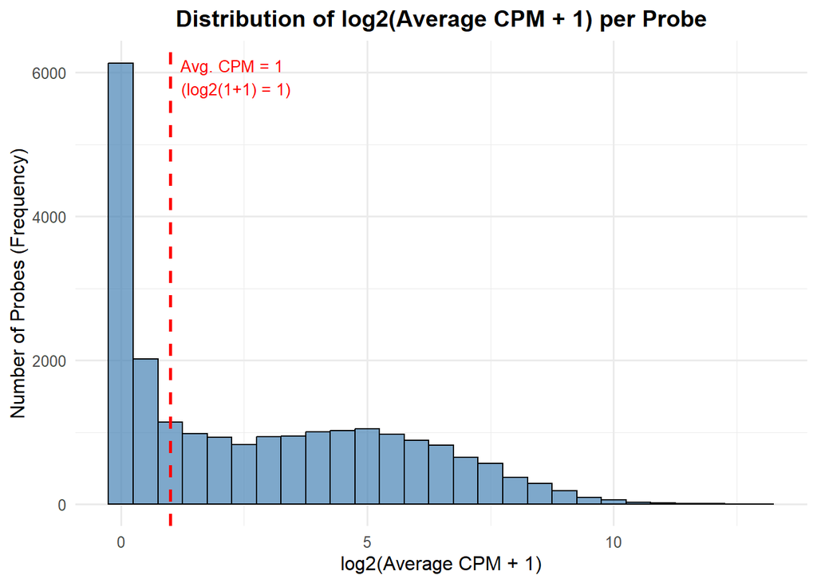

```r
#Prepare data for plotting:
#    - Filter out probes that were flagged for removal (as their CPM might be NA or irrelevant).
#    - Calculate log2(average_cpm + 1). Adding 1 avoids log2(0).
plot_data_log_cpm <- manifest %>%
  filter(flag_realignment != "Remove") %>% # Focus on probes we intend to keep/use
  filter(!is.na(average_cpm)) %>%        # Ensure average_cpm is not NA for calculation
  mutate(log2_avg_cpm_plus_1 = log2(average_cpm + 1))

# 2. Create the histogram
  cpm_distribution_plot <- ggplot(plot_data_log_cpm, aes(x = log2_avg_cpm_plus_1)) +
    geom_histogram(binwidth = 0.5, fill = "steelblue", color = "black", alpha = 0.7) +
    labs(
      title = "Distribution of log2(Average CPM + 1) per Probe",
      x = "log2(Average CPM + 1)",
      y = "Number of Probes (Frequency)"
    ) +
    theme_minimal(base_size = 12) +
    theme(
      plot.title = element_text(hjust = 0.5, face = "bold")
    )
  # 3. Add a vertical line for the threshold (average CPM < 1)
  threshold_log_value <- log2(1 + 1) # log2(Average CPM of 1 + 1)

  cpm_distribution_plot <- cpm_distribution_plot +
    geom_vline(
      xintercept = threshold_log_value,
      color = "red",
      linetype = "dashed",
      linewidth = 1
    ) +
    annotate(
      "text",
      x = threshold_log_value,
      y = Inf, # Position at the top
      label = paste0("Avg. CPM = 1\n(log2(1+1) = ", round(threshold_log_value,2), ")"),
      hjust = -0.1, # Horizontal adjustment (negative moves right from line)
      vjust = 1.5,  # Vertical adjustment (positive moves down from top)
      color = "red",
      size = 3.5
    )
   print(cpm_distribution_plot)
```

The histogram we generated successfully visualizes the distribution of log2(average CPM + 1) for our probes.

There is a distinct and large peak at the very low end of the expression spectrum (around log2(average CPM + 1) = 0), indicating a substantial number of probes with average CPM values close to zero. These are the lowly expressed or potentially non-expressed probes in your dataset.

**Exercise 17: Why did you use a log2 transformation here and why was it necessary to add 1 to the CPM values?**

Gene expression data, including CPM values, often has several characteristics that make log transformation beneficial, especially for visualization and some types of analysis:

Reduces Skewness: Gene expression data (like CPMs) is often highly skewed, with most genes at low levels and a few at very high levels. Log2 transformation makes this distribution more symmetrical, which is better for visualization and some statistical analyses.

Focuses on Fold Changes: Biologically, relative changes (fold changes) are often more important than absolute differences. Log2 transformation converts these multiplicative fold changes into additive differences, making them easier to interpret (e.g., a 2-fold increase becomes a change of +1 on the log2 scale).

Stabilizes Variance: It helps make the variance more constant across different expression levels.

Adding 1 (Pseudocount):

Handles Zeros: The main reason for adding 1 is that log2(0) is undefined. Many genes can have an average CPM of 0. By adding 1, you calculate log2(0 + 1) = log2(1) = 0, ensuring all values are defined and can be included in plots and analyses. Reduces Impact of Tiny Values: It also slightly dampens the effect of very small, near-zero CPM values, preventing them from becoming extremely large negative numbers after log transformation. ————————————————————————

**Exercise 18: How many probes have no expression measured in any of the samples?**

```r
# Identify probes with zero counts across all samples.
probes_with_zero_total_counts_logical <- (rowSums(countData) == 0)

# 2. Count how many such probes exist
number_of_probes_with_no_expression <- sum(probes_with_zero_total_counts_logical)
print(number_of_probes_with_no_expression)
```

```
## [1] 484
```

```r
# There is 484 probes with no expression
```

## 4.3 Relevance

We want to keep probes in our data if they are relevant for any of our experiments. Here, we define relevance as having a CPM above 1 for at least two thirds of the replicates.

**Exercise 19: How many experimental conditions do we have in this data and how many replicates are there for each?**

```r
# 1. Count the number of replicates for each experimental condition.
replicates_per_condition <- metaData %>%
  dplyr::count(
    mean_ID,
    sample_type,
    compound_name,
    compound_abbr,
    conc_amt,
    conc_unit,
    control_type,
    name = "number_of_replicates",
    sort = FALSE     # We will sort explicitly later if needed
  ) %>%
  dplyr::arrange(sample_type, compound_name, conc_amt) # Arrange for easier viewing

print(replicates_per_condition)
```

```
## # A tibble: 17 × 8
##    mean_ID     sample_type compound_name      compound_abbr conc_amt conc_unit
##    <chr>       <chr>       <chr>              <chr>            <dbl> <chr>
##  1 DMSOHigh_P1 Control     DMSO               DMSO             NA    <NA>
##  2 DMSOLow_P1  Control     DMSO               DMSO             NA    <NA>
##  3 Medium_P6   Control     Medium             Medium           NA    <NA>
##  4 CS1106_1_P1 Treatment   Diisopropanolamine DIPA              0.03 µM
##  5 CS1106_2_P1 Treatment   Diisopropanolamine DIPA              0.3  µM
##  6 CS1106_3_P1 Treatment   Diisopropanolamine DIPA              1    µM
##  7 CS1106_4_P1 Treatment   Diisopropanolamine DIPA              3.1  µM
##  8 CS1106_5_P1 Treatment   Diisopropanolamine DIPA             10    µM
##  9 CS1106_6_P1 Treatment   Diisopropanolamine DIPA             32    µM
## 10 CS1106_7_P1 Treatment   Diisopropanolamine DIPA            180    µM
## 11 CS1133_1_P6 Treatment   L-Tyrosine         Tyr               0.03 µM
## 12 CS1133_2_P6 Treatment   L-Tyrosine         Tyr               0.3  µM
## 13 CS1133_3_P6 Treatment   L-Tyrosine         Tyr               1    µM
## 14 CS1133_4_P6 Treatment   L-Tyrosine         Tyr               3.1  µM
## 15 CS1133_5_P6 Treatment   L-Tyrosine         Tyr              10    µM
## 16 CS1133_6_P6 Treatment   L-Tyrosine         Tyr              32    µM
## 17 CS1133_7_P6 Treatment   L-Tyrosine         Tyr             180    µM
## # ℹ 2 more variables: control_type <chr>, number_of_replicates <int>
```

```r
# 2. Determine the total number of unique experimental conditions.
total_experimental_conditions <- nrow(replicates_per_condition)
print(table(replicates_per_condition$number_of_replicates))
```

```
##
##  3  6
## 14  3
```

Top row (3 6): It means some conditions have 3 replicates, and some have 6 replicates. Bottom row (14 3): These are the frequencies (counts) for each of those replicate numbers. There are 14 experimental conditions that have 3 replicates each. There are 3 experimental conditions that have 6 replicates each. This confirms that your dataset consists of 14 + 3 = 17 unique experimental conditions in total, with most conditions having 3 replicates and a smaller number of conditions (likely the controls, based on previous exercises) having 6 replicates. In the table can ypu see the nummer of replicates in 17 unique experimental too.

**Exercise 20: Loop through these experimental conditions, calculating for each the percentage of replicates where each probe is above the 1 CPM threshold:**

**Hint**

First create a vector of the experimental conditions to use in a `for()` loop.

```r
# Create a vector of unique experimental conditions (mean_IDs)
experimental_conditions <- unique(replicates_per_condition$mean_ID)

# 2. Initialize a data frame to store the results.
if (is.matrix(cpmData)) {
  relevance_results_df <- data.frame(matrix(NA,
                                            nrow = nrow(cpmData),
                                            ncol = length(experimental_conditions)),
                                     row.names = rownames(cpmData))
} else {
   relevance_results_df <- data.frame(row.names = rownames(cpmData))
   for(condition_id_init in experimental_conditions) { # Renamed loop variable to avoid conflict
     relevance_results_df[[condition_id_init]] <- NA_real_
   }
}
colnames(relevance_results_df) <- experimental_conditions

# 3. Loop through each experimental condition
for (condition_id in experimental_conditions) {
  sample_ids_for_condition <- metaData %>%
    filter(mean_ID == condition_id) %>%
    pull(sample_ID)
  valid_sample_ids_for_condition <- intersect(sample_ids_for_condition, colnames(cpmData))

  if (length(valid_sample_ids_for_condition) > 0) {
    cpm_subset_for_condition <- cpmData[, valid_sample_ids_for_condition, drop = FALSE]
    is_above_threshold_matrix <- cpm_subset_for_condition > 1
    percentage_replicates_above_threshold <- rowMeans(is_above_threshold_matrix, na.rm = TRUE) * 100
    relevance_results_df[, condition_id] <- percentage_replicates_above_threshold
  } else {
    cat("Warning: No valid sample columns found in cpmData for condition_id:", condition_id, "\n")
    relevance_results_df[, condition_id] <- NA_real_
  }
}
print(head(relevance_results_df[, 1:min(3, ncol(relevance_results_df))], 6))
```

```
##          DMSOHigh_P1 DMSOLow_P1 Medium_P6
## A2M_1      100.00000  100.00000 100.00000
## AAMP_2     100.00000  100.00000 100.00000
## AARS1_3    100.00000  100.00000 100.00000
## AATF_4      66.66667   83.33333  83.33333
## ABCB1_12   100.00000  100.00000 100.00000
## ABCC2_22   100.00000  100.00000 100.00000
```

Values: The numbers in the table (e.g., 100.00000, 66.66667) are percentages. They indicate, for a given probe in a given experimental condition, the percentage of replicate samples where that probe’s expression level was above 1 CPM. For example:

For probe A2M_1: In 100% of the replicates for the DMSOHigh_P1 condition, its CPM was > 1. ————————————————————————

**Exercise 21: Add a column `n_relevant` to the relevance filter output which describes for how many experiments each probe is relevant. Merge the output with the probe manifest:**

**Hint**

The `rowSums()` function may come in handy :)

```r
#Define the relevance threshold
relevance_threshold_percentage <- (2/3 * 100) - 0.001

# 2. For each probe and condition, determine if it's "relevant
is_relevant_per_condition_matrix <- relevance_results_df > relevance_threshold_percentage
print(head(is_relevant_per_condition_matrix[, 1:min(3, ncol(is_relevant_per_condition_matrix))], 3))
```

```
##         DMSOHigh_P1 DMSOLow_P1 Medium_P6
## A2M_1          TRUE       TRUE      TRUE
## AAMP_2         TRUE       TRUE      TRUE
## AARS1_3        TRUE       TRUE      TRUE
```

```r
# 3. Calculate 'n_relevant': the number of conditions for which each probe is relevant.
n_relevant_per_probe <- rowSums(is_relevant_per_condition_matrix, na.rm = TRUE)

# 4. Create a data frame with 'probe_name'
relevance_summary_for_manifest <- data.frame(
  probe_name = rownames(relevance_results_df), # These are the GENESYMBOL_PROBEID names
  n_relevant = n_relevant_per_probe
)
print(head(relevance_summary_for_manifest, 3))
```

```
##         probe_name n_relevant
## A2M_1        A2M_1         17
## AAMP_2      AAMP_2         17
## AARS1_3    AARS1_3         17
```

```r
# 5. Merge 'n_relevant' into the main 'manifest' data frame.
if ("n_relevant" %in% colnames(manifest)) {
  manifest <- manifest %>% select(-n_relevant)
  cat("Removed existing 'n_relevant' column from 'manifest' before merging.\n")
}
manifest <- manifest %>%
  select(-any_of(c("n_relevant.x", "n_relevant.y")))


manifest <- manifest %>%
  left_join(relevance_summary_for_manifest, by = "probe_name")

# Show relevant columns including the new n_relevant.
print(head(manifest %>%
             select(probe_name, gene_symbol, flag_realignment, n_relevant) %>%
             arrange(desc(n_relevant)), 10)) # Show top 10 by n_relevant
```

```
## # A tibble: 10 × 4
##    probe_name   gene_symbol flag_realignment n_relevant
##    <chr>        <chr>       <chr>                 <dbl>
##  1 A1BG_25586   A1BG        Keep Unchanged           17
##  2 A1CF_87905   A1CF        Keep Unchanged           17
##  3 A2M_1        A2M         Keep Unchanged           17
##  4 A2M_12371    A2M         Keep Unchanged           17
##  5 A4GALT_88955 A4GALT      Keep Unchanged           17
##  6 AAAS_23947   AAAS        Keep Unchanged           17
##  7 AACS_17112   AACS        Keep Unchanged           17
##  8 AADAC_87800  AADAC       Keep Unchanged           17
##  9 AAGAB_23638  AAGAB       Keep Unchanged           17
## 10 AAK1_10468   AAK1        Keep Unchanged           17
```

For probe A2M_1, the value is TRUE for all three conditions shown (DMSOHigh_P1, DMSOLow_P1, Medium_P6). This means that probe A2M_1 was considered “relevant” (expressed above the threshold in at least 2/3 of replicates) in each of these three control conditions. The same applies to probes AAMP_2 and AARS1_3 for these three conditions.

The table shows you the probes that are most broadly “relevant” or consistently expressed above a baseline threshold across the highest number of different experimental conditions in our dataset.

## 4.4 Flag

We want to flag the lowly expressed probes in the manifest and remove them from our `countData`. These noisy, unreliable probes should not be included in our downstream analysis.

**Exercise 22: Flag any probes that do not pass the relevance filter for at least one experimental condition and remove them from `countData`:**

```r
# Add a relevance flag to the 'manifest'
if ("passes_relevance_filter" %in% colnames(manifest)) {
  manifest <- manifest %>% select(-passes_relevance_filter)
  cat("Removed existing 'passes_relevance_filter' column from 'manifest'.\n")
}
manifest <- manifest %>%
  select(-any_of(c("passes_relevance_filter.x", "passes_relevance_filter.y")))


manifest <- manifest %>%
  mutate(
    passes_relevance_filter = case_when(
      flag_realignment == "Remove" ~ FALSE, # Probes already marked for removal fail relevance
      !is.na(n_relevant) & n_relevant >= 1 ~ TRUE,  # Relevant in at least 1 condition
      TRUE ~ FALSE # Default to FALSE (e.g. if n_relevant is NA for some other reason, or 0)
    )
  )
print(table(manifest$passes_relevance_filter, useNA = "ifany"))
```

```
##
## FALSE  TRUE
##  7698 14835
```

```r
# 2. Identify the 'probe_name's of probes that PASS the relevance filter
probes_passing_relevance_filter <- manifest %>%
  filter(passes_relevance_filter == TRUE) %>%
  pull(probe_name)

num_probes_passing_filter <- length(probes_passing_relevance_filter)
cat("Number of probes passing the relevance filter (relevant in >= 1 condition):",
    num_probes_passing_filter, "\n\n")
```

```
## Number of probes passing the relevance filter (relevant in >= 1 condition): 14835
```

```r
# 3. Remove probes from 'countData' that do NOT pass the relevance filter.
probes_to_keep_in_countData_final <- intersect(rownames(countData), probes_passing_relevance_filter)

cat("Number of probes from the 'passes_relevance_filter' list that are actually in current countData:",
    length(probes_to_keep_in_countData_final), "\n")
```

```
## Number of probes from the 'passes_relevance_filter' list that are actually in current countData: 14835
```

```r
original_row_count_countData <- nrow(countData)


countData <- countData[probes_to_keep_in_countData_final, , drop = FALSE]
print(head(countData[, 1:min(5, ncol(countData))]))
```

```
##          CS1106_C1_P1_R1 CS1106_C1_P1_R2 CS1106_C1_P1_R3 CS1106_C2_P1_R1
## A2M_1                 13              20              17               7
## AAMP_2               342             375             386             345
## AARS1_3              513             501             424             645
## AATF_4                 8               6               9               8
## ABCB1_12             347             330             378             356
## ABCC2_22             586             653             792             497
##          CS1106_C2_P1_R2
## A2M_1                 10
## AAMP_2               303
## AARS1_3              486
## AATF_4                 3
## ABCB1_12             319
## ABCC2_22             694
```

There are 7698 probes were flagged as FALSE (meaning they did not pass the relevance filter. They were not relevant in at least one experimental condition). There are 14835 probes were flagged as TRUE (meaning they did pass the relevance filter. They were relevant in at least one experimental condition). This table shows the first 6 rows (probes) and the first 4 or 5 sample columns of your countData data frame after it has been filtered. ————————————————————————

**Exercise 23: Visualize and interpret the distribution of `n_relevant`:**

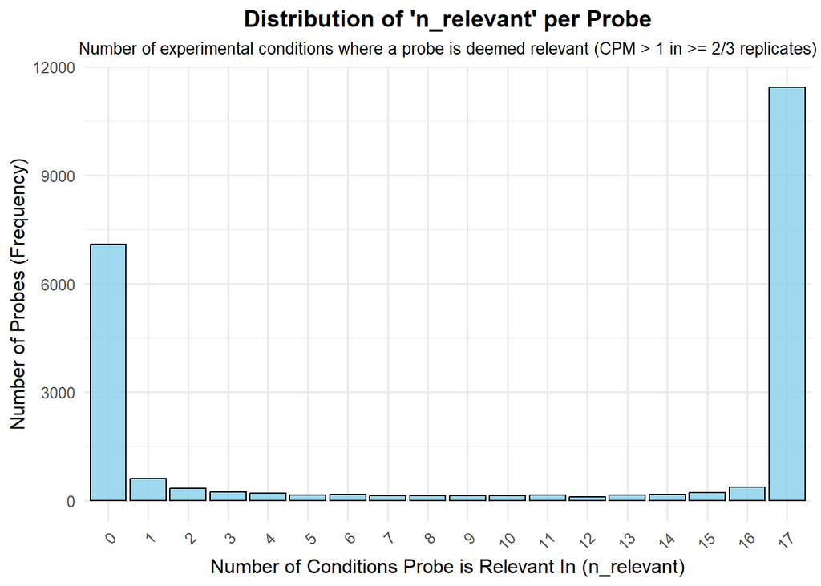

```r
#
plot_data_n_relevant <- manifest %>%
  filter(flag_realignment != "Remove") %>% # Consider only probes not marked for removal
  filter(!is.na(n_relevant))              # Ensure n_relevant is not NA



n_relevant_distribution_plot <- ggplot(plot_data_n_relevant, aes(x = factor(n_relevant))) +
    geom_bar(fill = "skyblue", color = "black", alpha = 0.8) +
    labs(
      title = "Distribution of 'n_relevant' per Probe",
      subtitle = "Number of experimental conditions where a probe is deemed relevant (CPM > 1 in >= 2/3 replicates)",
      x = "Number of Conditions Probe is Relevant In (n_relevant)",
      y = "Number of Probes (Frequency)"
    ) +
    theme_minimal(base_size = 12) +
    theme(
      plot.title = element_text(hjust = 0.5, face = "bold"),
      plot.subtitle = element_text(hjust = 0.5, size = 10),
      axis.text.x = element_text(angle = 45, hjust = 1) # Angle x-axis labels if many categories
  )


print(n_relevant_distribution_plot)
```

The Plot: The distribution is quite bimodal, with large groups of probes at n_relevant = 0 and n_relevant = 17, and very few in between. This makes it clear that most probes are either not relevant in any condition or relevant in all/most conditions. If you were to set a threshold, a common one might be to keep probes relevant in at least one condition (n_relevant >= 1). This plot clearly shows how many probes would be kept or discarded at different n_relevant thresholds.

**Exercise 24: Check the distribution of log2(CPM + 1) values coloured by the relevant filter flag. Has the peak of lowly expressed genes been reduced?**

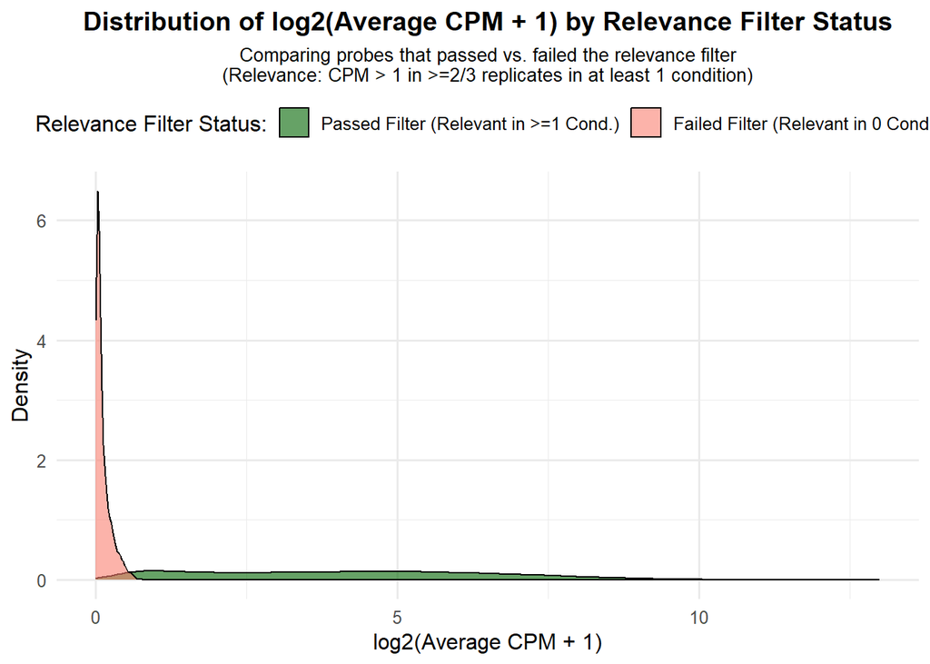

```r
# 1. Prepare data for plotting:
plot_data_relevance_dist <- manifest %>%
  filter(flag_realignment != "Remove") %>%
  filter(!is.na(average_cpm)) %>%
  mutate(
    log2_avg_cpm_plus_1 = log2(average_cpm + 1),
    passes_relevance_filter = if_else(is.na(passes_relevance_filter), FALSE, passes_relevance_filter),
    passes_relevance_filter = factor(passes_relevance_filter,
                                     levels = c(TRUE, FALSE),
                                     labels = c("Passed Filter (Relevant in >=1 Cond.)",
                                                "Failed Filter (Relevant in 0 Cond.)"))
  )

# This 'if' condition checks if there's any data left to plot after filtering.
if (nrow(plot_data_relevance_dist) > 0) {

  # 2. Create the density plot
  relevance_dist_plot <- ggplot(plot_data_relevance_dist, aes(x = log2_avg_cpm_plus_1, fill = passes_relevance_filter)) +
    geom_density(alpha = 0.6, na.rm = TRUE) +
    scale_fill_manual(values = c("Passed Filter (Relevant in >=1 Cond.)" = "darkgreen",
                                 "Failed Filter (Relevant in 0 Cond.)" = "salmon")) +
    labs(
      title = "Distribution of log2(Average CPM + 1) by Relevance Filter Status",
      subtitle = "Comparing probes that passed vs. failed the relevance filter\n(Relevance: CPM > 1 in >=2/3 replicates in at least 1 condition)",
      x = "log2(Average CPM + 1)",
      y = "Density",
      fill = "Relevance Filter Status:"
    ) +
    theme_minimal(base_size = 12) +
    theme(
      plot.title = element_text(hjust = 0.5, face = "bold"),
      plot.subtitle = element_text(hjust = 0.5, size = 10),
      legend.position = "top"
    )


  # Display the plot
  print(relevance_dist_plot)

} else {
  cat("No data available for plotting 'log2_avg_cpm_plus_1' distribution by relevance.\nPlease check the 'manifest' object and the results of previous exercises.\n")
}
```

The plot shows two distributions:

The “Failed Filter” probes (salmon): These probes (not relevant in any condition) form a very tall, sharp peak near zero, indicating they are almost all very lowly or non-expressed. The “Passed Filter” probes (green): For these probes (relevant in at least one condition), the extreme peak of lowly expressed genes is greatly reduced. Their expression values are more spread out and shifted towards higher levels compared to the “failed” group. The relevance filter has significantly reduced the peak of lowly expressed genes among the probes that passed the filter. This means the remaining dataset is enriched for probes with more robust and detectable expression. ————————————————————————